# chapter02_快速探索数据

## 2.5 绘制箱线图

- 使用`plot()`函数绘制箱线图时向其传递两个向量：x和y。当x为因子型变量（与数值型变量对应）时，它会默认绘制箱线图：

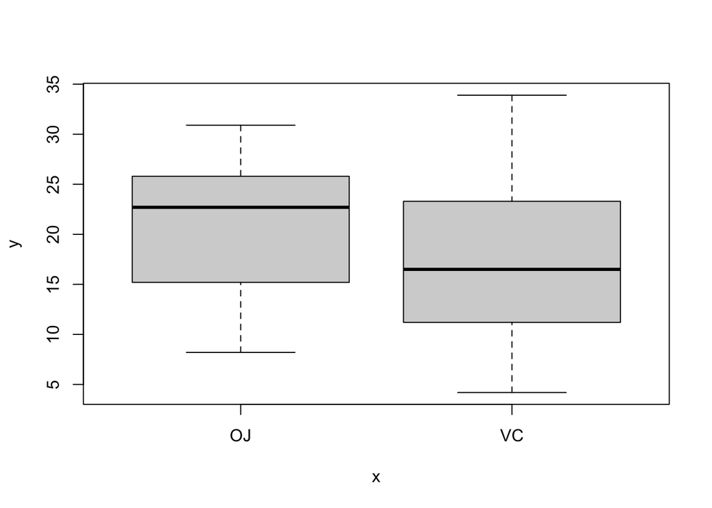

```r
> plot(ToothGrowth$supp,ToothGrowth$len)
```

- 当两个参数向量包含在同一个数据框中时，也可以使用公式语法。公式语法允许我们在x轴上使用变量组合：

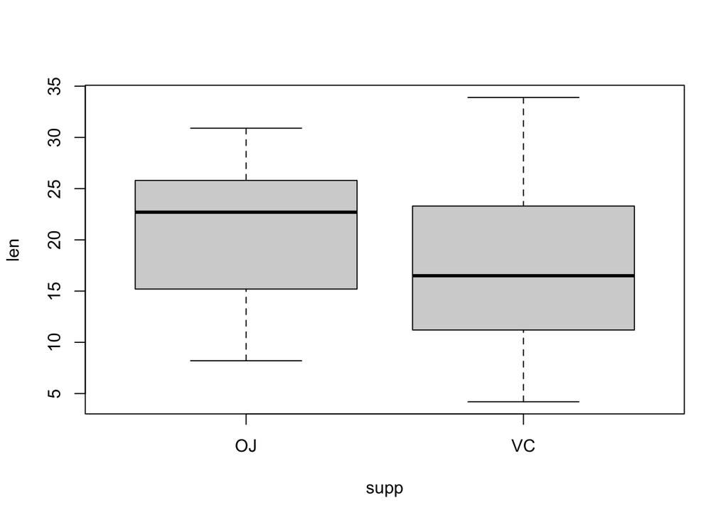

```r
> # 公式语法
> boxplot(len~supp,data = ToothGrowth)
```

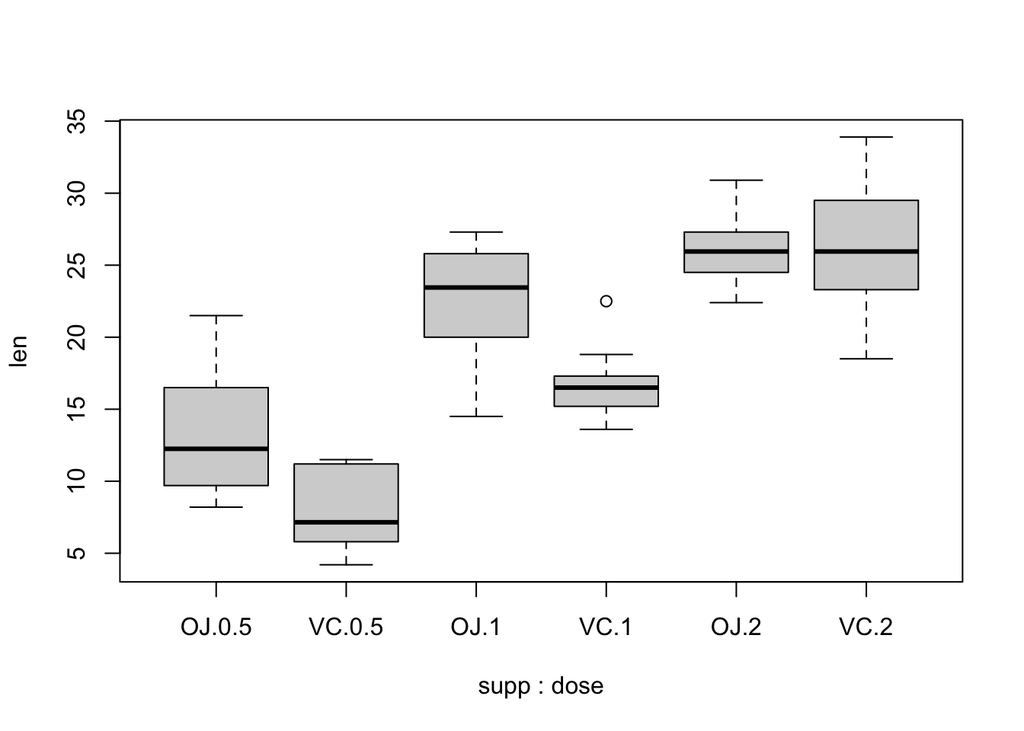

```r
> # 在x轴上引入两变量的交互
> boxplot(len~supp+dose,data = ToothGrowth)
```

- 对于ggplot2包，你可以使用`qplot()`函数绘制同样的图形，使用时将参数设定为`geom="boxplot"`：

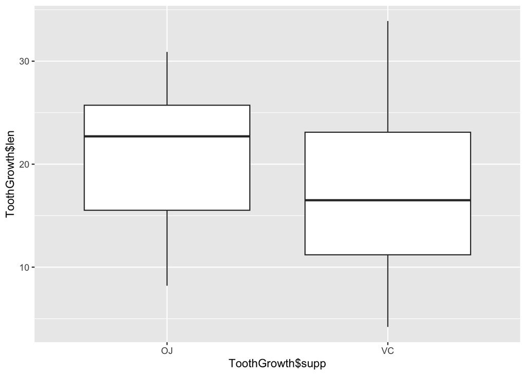

```r
> library(ggplot2)
> qplot (ToothGrowth$supp,ToothGrowth$len,geom="boxplot")
```

- 当两个参数向量在同一个数据框内时，则可以使用下面的语句：

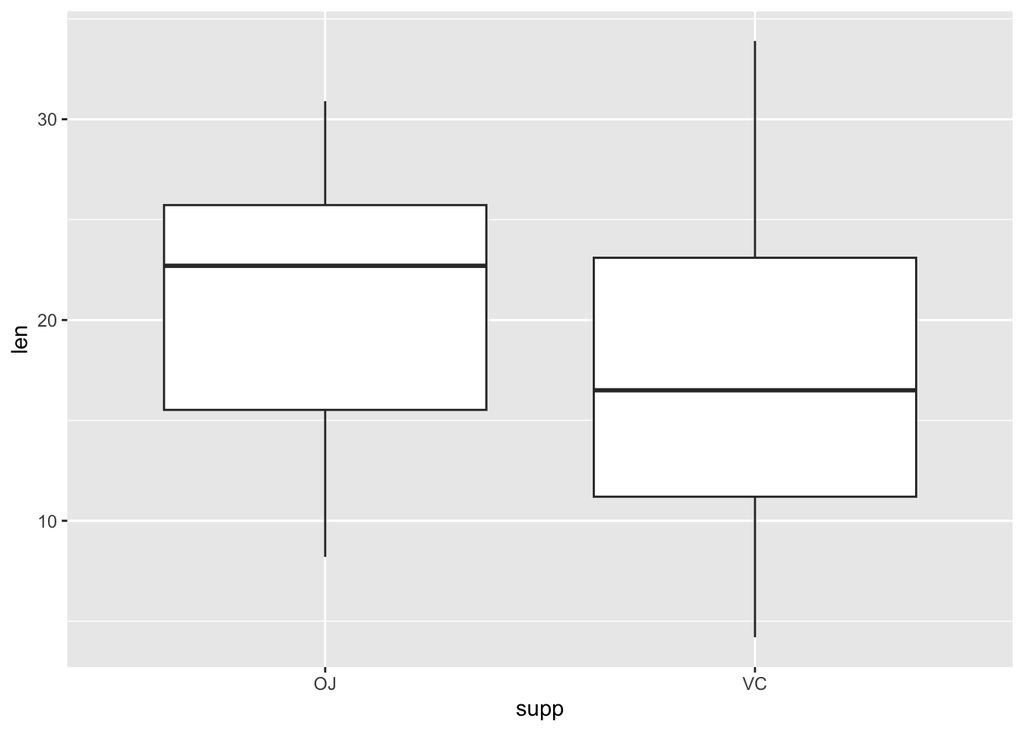

```r
> qplot(supp,len,data=ToothGrowth,geom="boxplot")
```

```r
> #这等价于
> # ggplot(ToothGrowth,aes(x=supp,y=len))+geom_boxplot()
```

- 使用`interaction()`函数将分组变量组合在一起也可以绘制基于多分组变量的箱线图。本例中，dose变量是数值型，因此，我们必须先将其转化为因子型变量，再将其作为分组变量：

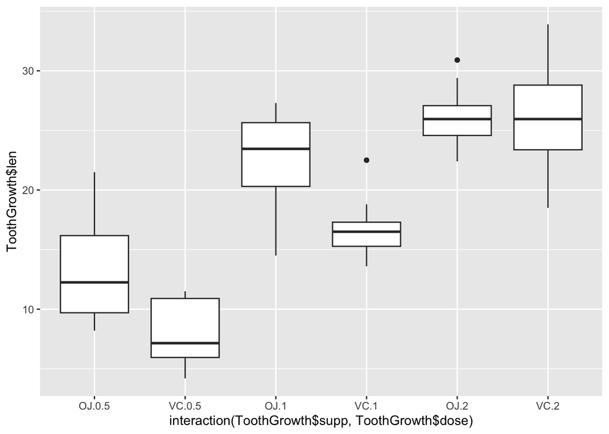

```r
> #使用三个独立的向量参数
> qplot(interaction(ToothGrowth$supp,ToothGrowth$dose),ToothGrowth$len,geom="boxplot") #也可以以数据框中的列作为参数
```

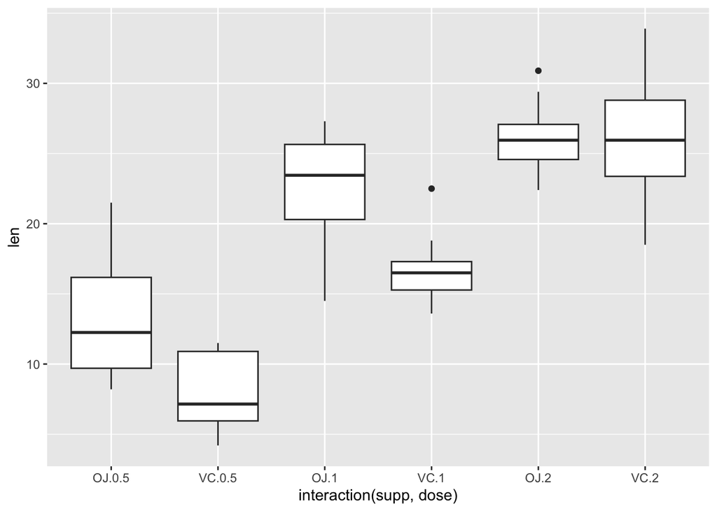

```r
> qplot(interaction(supp,dose),len,data=ToothGrowth,geom="boxplot")
```

```r
> #这等价于
> # ggplot(ToothGrowth,aes(x=interaction(supp,dose),y=len)) + geom_boxplot()
```

- 更多关于绘制箱线图的内容参见6.6节。

## 2.6 绘制函数图像

- 可以使用`curve()`函数绘制函数图像。使用时需向其传递一个关于变量x的表达式：

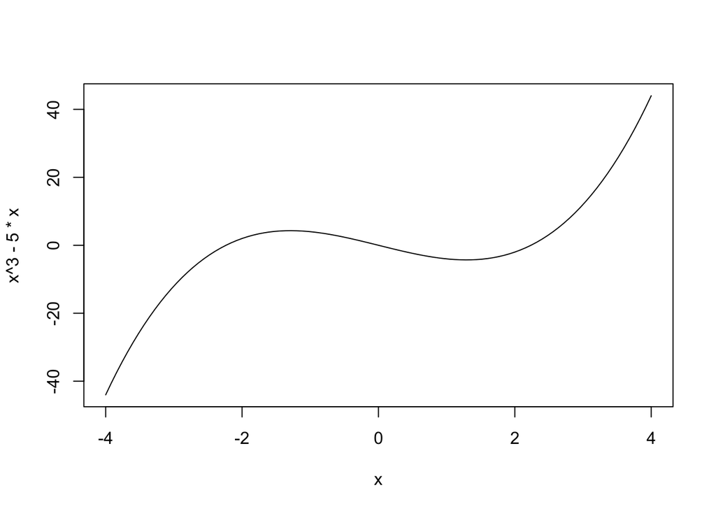

```r
> curve(x^3-5*x,from = -4,to=4)
```

- 你可以绘制任何一个以数值型向量作为输入且以数值型向量作为输出的函数图像，包括你自己定义的函数：
- 将参数设置为`add=TRUE`可以向已有图形添加函数图像：

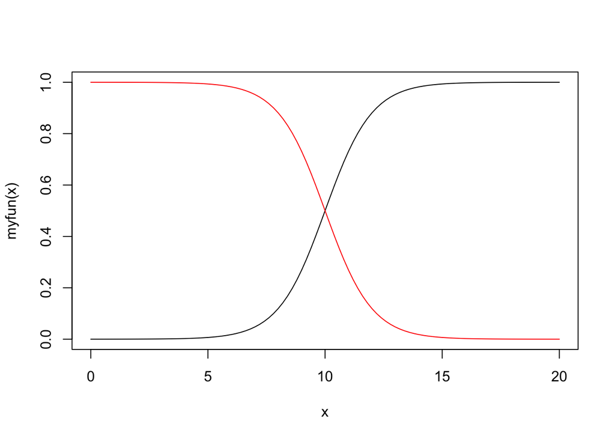

```r
> #绘制用户自定义的函数图像
> myfun <- function(xvar){
+   1/(1+exp(-xvar+10))
+ }
> curve(myfun(x),from=0,to=20)
> #添加直线
> curve(1-myfun(x),add=TRUE,col ="red")
```

- 对于ggplot2，可以使用`ggplot()`函数绘制得到同样的结果。使用时需向其传递一个输入和输出皆为数值型向量的函数：

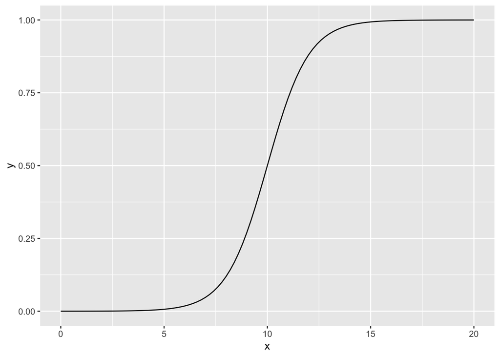

```r
> library(ggplot2)
> #将×轴的取值范围设定为0到20
> ggplot(data.frame(x=c(0,20)),aes(x=x)) + stat_function(fun=myfun,geom="line")
```

- 更多关于绘制函数图像的内容参见13.2节。